# Power Analysis

2022-08-26

```r
mytheme <- function (palette = "black_and_white", base_size = 14, base_family = "sans",
                     base_fontface = "plain", base_line_size = base_size/20, base_rect_size = base_size/14,
                     axis_text_angle = 0, border = FALSE) {

  is_bool <- function(x) {
    is_logical(x, n = 1) && !is.na(x)
  }
  angle <- axis_text_angle[1]
   if (!angle %in% c(0, 45, 90, 270))
     stop(sprintf("'axis_text_angle' must be one of [%s]",
                  paste(c(0, 45, 90, 270), collapse = ", ")), ".\nFor other angles, use the guide_axis() function in ggplot2 instead",
          call. = FALSE)
   if (!palette %in% names(ggprism::ggprism_data$themes)) {
     stop("The palette ", paste(palette), " does not exist.\n         See names(ggprism_data$themes) for valid palette names")
   }
   colours <- tibble::deframe(ggprism::ggprism_data$themes[[palette]])
   if (!is_bool(border)) {
     stop("border must be either: TRUE or FALSE")
   }
   else {
     if (border) {
       panel.border <- element_rect(fill = NA)
       axis.line <- element_blank()
     }
     else if (!border) {
       panel.border <- element_blank()
       axis.line <- element_line()
     }
   }
   t <- theme(line = element_line(colour = colours["axisColor"],
                                  size = base_line_size, linetype = 1, lineend = "square"),
              rect = element_rect(fill = "white", colour = colours["axisColor"],
                                  size = base_rect_size, linetype = 1), text = element_text(family = base_family,
                                                                                            face = base_fontface, colour = colours["graphTitleColor"],
                                                                                            size = base_size, lineheight = 0.9, hjust = 0.5,
                                                                                            vjust = 0.5, angle = 0, margin = margin(), debug = FALSE),
              prism.ticks.length = unit(base_size/50, "pt"), axis.line = axis.line,
              axis.line.x = NULL, axis.line.y = NULL, axis.text = element_text(size = rel(0.95),
                                                                               colour = colours["axisLabelColor"]), axis.text.x = element_text(margin = margin(t = 0.8 *
                                                                                                                                                                 base_size/4), angle = axis_text_angle, hjust = ifelse(axis_text_angle %in%
                                                                                                                                                                                                                         c(45, 90, 270), 1, 0.5), vjust = ifelse(axis_text_angle %in%
                                                                                                                                                                                                                                                                   c(0, 90, 270), 0.5, 1)), axis.text.x.top = element_text(margin = margin(b = 0.8 *
                                                                                                                                                                                                                                                                                                                                             base_size/4), vjust = 0), axis.text.y = element_text(margin = margin(r = 0.5 *
                                                                                                                                                                                                                                                                                                                                                                                                                    base_size/4), hjust = 1), axis.text.y.right = element_text(margin = margin(l = 0.5 *
                                                                                                                                                                                                                                                                                                                                                                                                                                                                                                 base_size/4), hjust = 0), axis.ticks = element_line(),
              axis.ticks.length = unit(3, "points"), axis.ticks.length.x = NULL,
              axis.ticks.length.x.top = NULL, axis.ticks.length.x.bottom = NULL,
              axis.ticks.length.y = NULL, axis.ticks.length.y.left = NULL,
              axis.ticks.length.y.right = NULL, axis.title = element_text(colour = colours["axisTitleColor"]),
              axis.title.x = element_text(margin = margin(t = base_size *
                                                            0.6), vjust = 1), axis.title.x.top = element_text(margin = margin(b = base_size *
                                                                                                                                0.6), vjust = 0), axis.title.y = element_text(angle = 90,
                                                                                                                                                                              margin = margin(r = base_size * 0.6), vjust = 1),
              axis.title.y.right = element_text(angle = -90, margin = margin(l = base_size *
                                                                               0.6), vjust = 0), legend.background = element_blank(),
              legend.spacing = unit(base_size, "pt"), legend.spacing.x = NULL,
              legend.spacing.y = NULL, legend.margin = margin(base_size/2,
                                                              base_size/2, base_size/2, base_size/2), legend.key = element_blank(),
              legend.key.size = unit(1.2, "lines"), legend.key.height = NULL,
              legend.key.width = unit(base_size * 1.8, "pt"), legend.text = element_text(size = rel(0.8),
                                                                                         face = "plain"), legend.text.align = NULL, legend.title = element_blank(),
              legend.title.align = NULL, legend.position = "right",
              legend.direction = NULL, legend.justification = "center",
              legend.box = NULL, legend.box.margin = margin(0, 0, 0,
                                                            0, "cm"), legend.box.background = element_blank(),
              legend.box.spacing = unit(base_size, "pt"), panel.background = element_rect(fill = ifelse(palette ==
                                                                                                          "office", colours["plottingAreaColor"], NA), colour = NA),
              panel.border = panel.border, panel.grid = element_blank(),
              panel.grid.minor = element_blank(), panel.spacing = unit(base_size/2,
                                                                       "pt"), panel.spacing.x = NULL, panel.spacing.y = NULL,
              panel.ontop = FALSE, strip.background = element_blank(),
              strip.text = element_text(colour = colours["axisTitleColor"],
                                        size = rel(0.8), margin = margin(base_size/2.5, base_size/2.5,
                                                                         base_size/2.5, base_size/2.5)), strip.text.x = element_text(margin = margin(b = base_size/3)),
              strip.text.y = element_text(angle = -90, margin = margin(l = base_size/3)),
              strip.text.y.left = element_text(angle = 90), strip.placement = "inside",
              strip.placement.x = NULL, strip.placement.y = NULL, strip.switch.pad.grid = unit(base_size/4,
                                                                                               "pt"), strip.switch.pad.wrap = unit(base_size/4,
                                                                                                                                   "pt"), plot.background = element_rect(fill = colours["pageBackgroundColor"],
                                                                                                                                                                         colour = NA), plot.title = element_text(size = rel(1.2),
                                                                                                                                                                                                                 hjust = 0.5, vjust = 1, margin = margin(b = base_size)),
              plot.title.position = "panel", plot.subtitle = element_text(hjust = 0.5,
                                                                          vjust = 1, margin = margin(b = base_size/2)), plot.caption = element_text(size = rel(0.8),
                                                                                                                                                    hjust = 1, vjust = 1, margin = margin(t = base_size/2)),
              plot.caption.position = "panel", plot.tag = element_text(size = rel(1.2),
                                                                       hjust = 0.5, vjust = 0.5), plot.tag.position = "topleft",
              plot.margin = margin(base_size/2, base_size/2, base_size/2,
                                   base_size/2), complete = TRUE)
   ggprism::ggprism_data$themes[["all_null"]] %+replace% t
 }
```

```r
# Load libraries
library(dplyr)
library(purrr)
library(stringr)
library(ggplot2)
library(ggpubr)
library(jcolors)
library(cowplot)
library(ggprism)
library(tidybayes)
library(reshape2)
library(parallel)
library(rstan)


effect_size = c("Paper Effect Size", "Paper Effect Size/2", "Paper Effect Size/3",
    "Paper Effect Size/4")
# Functions
psoftmax <- function(b) exp(c(0, b))/sum(exp(c(0, b)))

words_replace <- function(variable, words_to_replace, replace_with = "") {

    library(dplyr)
    if (!require(dplyr)) {
        install.packages("dplyr")
        library(dplyr)
    }

    # variable <- enquo(variable) var <- select(data, !!variable) %>% .[,]

    if (!is.character(variable))
        variable <- as.character(variable)

    for (word_i in 1:length(words_to_replace)) {
        word_to_rm_index <- which(str_detect(variable, fixed(words_to_replace[word_i])))

        if (any(word_to_rm_index)) {
            words_to_replace_i <- words_to_replace[word_i]
            new_words <- sapply(seq_along(word_to_rm_index), function(i) {
                variable[word_to_rm_index][i] <- gsub(words_to_replace_i, replace_with,
                  variable[word_to_rm_index][i], fixed = TRUE)
            })
            variable[word_to_rm_index] <- new_words
        } else {
            warning(paste0("Sting '", words_to_replace, "' not found"))
        }
    }

    return(variable)
}

seq_vector <- function(x) {
    idx <- c(which(diff(x) != 0), length(x))
    time <- c(idx[1], diff(idx))
    rep(x = 1:length(idx), times = time)
}

# Load data
data_short <- readRDS("../Pilot/Short Version/Data/data_short.rds")$data %>%
    mutate(subject = 1:n()) %>%
    rename(age = Age., A3 = A3.)

questions <- readRDS("../Pilot/Short Version/Data/data_short.rds")$question

# ----- Mental Accounting ----- # Remove final questionnaires
data_short_MA <- data_short[, -(48:75)]
# Remove response time
idx_time <- str_detect(names(data_short_MA), "time_")
data_short_MA <- data_short_MA[, !idx_time]

data_short_MA <- data_short_MA %>%
    rename_with(~gsub(".", "", .x, fixed = TRUE)) %>%
    rename_with(toupper, .cols = -contains("subject"))

n_sbj <- nrow(data_short_MA)
```

## Mr. A vs Mr. B2

#### Power Analysis

```stan
functions {
  /*
   * Args:
   *   y:  response value 0: A, 1: B, 2: No difference
   *   ds: different (0|1) - same (2) probability
   *   cA: conditional (different) A probability
   * Returns:
   *   a scalar to be added to the log posterior
   */
   real mental_accounting_lpdf(real y,  real ds, real cA) {
     if (y == 0) { // Stay (Explore)
       return bernoulli_lpmf(1 | ds) + bernoulli_lpmf(1 | cA);
     } else if (y == 1) { // Switch (Explore)
       return bernoulli_lpmf(1 | ds) + bernoulli_lpmf(0 | cA);
     } else { // Select
       return bernoulli_lpmf(0 | ds);
     }
   }
}

data {
  int<lower=1> N;  // total number of observations
  vector[N] Y;  // response variable
  int<lower=1> K_ds;  // number of population-level effects
  matrix[N, K_ds] X_ds;  // population-level design matrix
  int<lower=1> K_cA;  // number of population-level effects
  matrix[N, K_cA] X_cA;  // population-level design matrix

  int prior_only;  // should the likelihood be ignored?
}
parameters {
  vector[K_ds] b_ds;  // population-level effects
  vector[K_cA] b_cA;  // population-level effects
}

transformed parameters {
}

model {
  // likelihood including constants
  if (!prior_only) {
    // initialize different - same linear predictor term
    vector[N] ds = X_ds * b_ds;
    // initialize linear predictor term
    vector[N] cA = X_cA * b_cA;

    for (n in 1:N) {
      // apply the inverse link function
      ds[n] = inv_logit(ds[n]);
    }
    for (n in 1:N) {
      // apply the inverse link function
      cA[n] = inv_logit(cA[n]);
    }
    for (n in 1:N) {
      target += mental_accounting_lpdf(Y[n] | ds[n], cA[n]);
    }
  }
  // priors including constants
  target += normal_lpdf(b_ds | 0, 5);
  target += normal_lpdf(b_cA | 0, 5);
}
```

```r
# ---- Power Calculation ---- #
nModels <- 4
nChains <- 2
nClusters <- nModels*nChains

n_sim <- 200
n_sbj_range <- c(10, 50, 100, 150)

# Calculate the probability of responding 'different'
logit = function(p) log(p/(1-p))

# Effect found in the paper Thaler 1985
n_sbj    = 87
scenario = 1:4
A        = c(56, 66, 22, 19)
B        = c(16, 14, 61, 63)
ds       = (A+B)/n_sbj # Probability to choose Different
cA       = A/(A+B)

effect_ds = logit(ds)
effect_cA = logit(cA)

sim_y <- function(sbj, mu_ds, mu_cA){

  std      = 0.5
  n_sbj    = 87
  scenario = 1:4
  A        = c(56, 66, 22, 19)
  B        = c(16, 14, 61, 63)
  ds       = (A+B)/n_sbj # Probability to choose Different
  cA       = A/(A+B)

  # Probability of 'Different' and Conditional Probability of 'A'
  p_ds <- plogis(mu_ds)
  p_cA <- plogis(mu_cA)

  response <- sapply( scenario, function(i){
    y_ds <- rbinom( 1, 1, p_ds[i])
    if( y_ds==1 ){
      response = rbinom(1, 1, (1-cA[i]) )
    } else {
      response = 2
    }
    response
  })

  return( data.frame(subject=sbj, response, scenario=paste0('s', scenario)) )
}


samplingfunction <- function(x){


  #Simulate data
  data_sim <- purrr::map_dfr(seq_len(n),
                             sim_y, mu_ds=effect_ds,
                             mu_cA=effect_cA)

  ## Create Stan Data
  X <- model.matrix(~ 0 + scenario, data_sim)

  #Stan Data
  stan_data <- list(
    N        = nrow(data_sim),
    Y        = data_sim$response,
    X_ds     = X,
    X_cA     = X,
    K_ds     = ncol(X),
    K_cA     = ncol(X),

    N_sbj    = n,
    J_sbj    = data_sim$subject,

    prior_only = 0
  )

  # Fit the model
  fit <- rstan::sampling(mixture_scenario_1,
                         iter   = 2000,
                         cores  = 2,
                         chains = 2,
                         pars   = c('b_ds', 'b_cA'),
                         data   = stan_data,
                         refresh = 0,
                         save_warmup = FALSE)
  efit <- rstan::extract(fit)
  colnames(efit$b_cA) <- c(
                            'gain-gain VS gain',
                            'loss-loss VS loss',
                            'gain-loss VS gain',
                            'loss-gain VS loss'
                          )

  df <- as.data.frame(efit$b_cA)
  gain <- with(df, `gain-gain VS gain` - `gain-loss VS gain`)
  loss <- with(df, `loss-loss VS loss` - `loss-gain VS loss`)

  rbind(
    data.frame(
      estimate = mean(gain),
      lwr      = quantile(gain, probs=0.025),
      upr      = quantile(gain, probs=0.975),
      type     = 'gain',
      N        = n
    ),

    data.frame(
      estimate = mean(loss),
      lwr      = quantile(loss, probs=0.025),
      upr      = quantile(loss, probs=0.975),
      type     = 'loss',
      N        = n
    )
  )

}

samplingfunction2 <- function(x){

  #Simulate data
  data_sim <- purrr::map_dfr(seq_len(n),
                             sim_y, mu_ds=effect_ds/2,
                             mu_cA=effect_cA/2)

  ## Create Stan Data
  X <- model.matrix(~ 0 + scenario, data_sim)

  #Stan Data
  stan_data <- list(
    N        = nrow(data_sim),
    Y        = data_sim$response,
    X_ds     = X,
    X_cA     = X,
    K_ds     = ncol(X),
    K_cA     = ncol(X),

    N_sbj    = n,
    J_sbj    = data_sim$subject,

    prior_only = 0
  )

  # Fit the model
  fit <- rstan::sampling(mixture_scenario_1,
                         iter   = 2000,
                         cores  = 2,
                         chains = 2,
                         pars   = c('b_ds', 'b_cA'),
                         data   = stan_data,
                         refresh = 0,
                         save_warmup = FALSE)
  efit <- rstan::extract(fit)
  colnames(efit$b_cA) <- c(
                            'gain-gain VS gain',
                            'loss-loss VS loss',
                            'gain-loss VS gain',
                            'loss-gain VS loss'
                          )

  df <- as.data.frame(efit$b_cA)
  gain <- with(df, `gain-gain VS gain` - `gain-loss VS gain`)
  loss <- with(df, `loss-loss VS loss` - `loss-gain VS loss`)

  rbind(
    data.frame(
      estimate = mean(gain),
      lwr      = quantile(gain, probs=0.025),
      upr      = quantile(gain, probs=0.975),
      type     = 'gain',
      N        = n
    ),

    data.frame(
      estimate = mean(loss),
      lwr      = quantile(loss, probs=0.025),
      upr      = quantile(loss, probs=0.975),
      type     = 'loss',
      N        = n
    )
  )

}
```

```r
power <- data.frame()
for (n in n_sbj_range) {
    message("\n\nN Subjects: ", n, "\n")

    message("Setting up Clusters...")
    cl <- parallel::makeCluster(nClusters, outfile = "")
    parallel::clusterExport(cl, c("mixture_scenario_1", "n_sbj_range", "sim_y", "effect_ds",
        "effect_cA", "n"))

    out <- map_dfr(seq_len(round(n_sim/nModels)), function(i) {
        message("\r", "Simulation: ", i * nModels, "/", n_sim, appendLF = FALSE)
        parallel::parLapply(cl, 1:nModels, samplingfunction)
    })
    power <- rbind(power, out)

    message("Shutting down Clusters...")
    parallel::stopCluster(cl)
}
```

```r
power2 <- data.frame()
for (n in n_sbj_range) {
    message("\n\nN Subjects: ", n, "\n")

    message("Setting up Clusters...")
    cl <- parallel::makeCluster(nClusters, outfile = "")
    parallel::clusterExport(cl, c("mixture_scenario_1", "n_sbj_range", "sim_y", "effect_ds",
        "effect_cA", "n"))

    out <- map_dfr(seq_len(round(n_sim/nModels)), function(i) {
        message("\r", "Simulation: ", i * nModels, "/", n_sim, appendLF = FALSE)
        parallel::parLapply(cl, 1:nModels, samplingfunction2)
    })
    power2 <- rbind(power2, out)

    message("Shutting down Clusters...")
    parallel::stopCluster(cl)
}
```

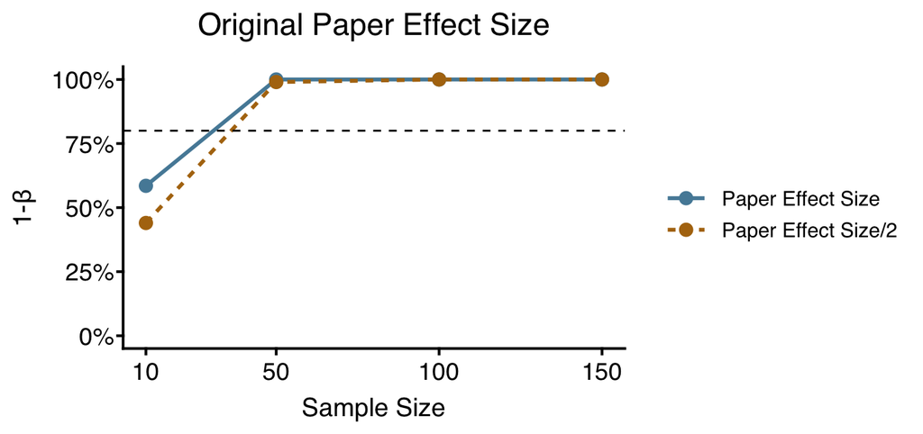

```r
pw1 <- power %>%
    mutate(sim_n = rep(rep(1:n_sim, each = 2), length(n_sbj_range))) %>%
    mutate(is_sign = ifelse(lwr > 0, TRUE, FALSE)) %>%
    group_by(sim_n, N) %>%
    mutate(is_significant = all(is_sign)) %>%
    filter(row_number() == 1) %>%
    group_by(N) %>%
    summarise(power = mean(is_significant)) %>%
    mutate(effsize = "Paper Effect Size")

pw2 <- power2 %>%
    mutate(sim_n = rep(rep(1:n_sim, each = 2), length(n_sbj_range))) %>%
    mutate(is_sign = ifelse(lwr > 0, TRUE, FALSE)) %>%
    group_by(sim_n, N) %>%
    mutate(is_significant = all(is_sign)) %>%
    filter(row_number() == 1) %>%
    group_by(N) %>%
    summarise(power = mean(is_significant)) %>%
    mutate(effsize = "Paper Effect Size/2")

rbind(pw1, pw2) %>%
    ggplot(aes(N, power, color = effsize, linetype = effsize)) + geom_line(size = 1) +
    geom_point(size = 3) + geom_hline(yintercept = 0.8, linetype = 2) + scale_y_continuous(limits = c(0,
    1), labels = scales::percent) + scale_x_continuous(breaks = n_sbj_range) + labs(x = "Sample Size",
    y = "1-β", title = "Original Paper Effect Size") + scale_color_jcolors(palette = "pal6") +
    mytheme()
```

#### Questions

Mr. A was given two tickets to the Regional lottery. He won $50 in one lottery and $25 in the other.  
Mr. B was given a ticket to a single, larger Regional lottery. He won $75.  
Who is happier?

A/B/No difference

Mr. A received a letter from the IRS saying that he made a minor arithmetical mistake on his tax return and owed $100. He received a similar letter the same day from his state income tax authority saying he owed $50. There were no other repercussions from either mistake.  
Mr. B received a letter from the IRS saying he made a minor arithmetical mistake on his tax return and owed $150. There were no other repercussions from this mistake.  
Who more upset?

A/B/No difference

Mr. A bought his first National lottery ticket and won $100. Also, in a freak accident, he damaged the rug in his apartment and had to pay the landlord $80.  
Mr. B bought his first National lottery ticket and won $20.  
Who is happier?

A/B/No difference

Mr. A’s car was damaged in a parking lot. He had to spend $200 to repair the damage. The same day the car was damaged, he won $25 in the office holiday raffle.  
Mr. B’s car was damaged in a parking lot. He had to spend $175 to repair the damage.  
Who is more upset?

A/B/No difference

#### Stan Code

```
functions {
  /*
   * Args:
   *   y:  response value 0: A, 1: B, 2: No difference
   *   ds: different (0|1) - same (2) probability
   *   cA: conditional (different) A probability
   * Returns:
   *   a scalar to be added to the log posterior
   */
   real mental_accounting_lpdf(real y,  real ds, real cA) {
     if (y == 0) { // Stay (Explore)
       return bernoulli_lpmf(1 | ds) + bernoulli_lpmf(1 | cA);
     } else if (y == 1) { // Switch (Explore)
       return bernoulli_lpmf(1 | ds) + bernoulli_lpmf(0 | cA);
     } else { // Select
       return bernoulli_lpmf(0 | ds);
     }
   }
}

data {
  int<lower=1> N;  // total number of observations
  vector[N] Y;  // response variable
  int<lower=1> K_ds;  // number of population-level effects
  matrix[N, K_ds] X_ds;  // population-level design matrix
  int<lower=1> K_cA;  // number of population-level effects
  matrix[N, K_cA] X_cA;  // population-level design matrix

  int prior_only;  // should the likelihood be ignored?
}
parameters {
  vector[K_ds] b_ds;  // population-level effects
  vector[K_cA] b_cA;  // population-level effects
}

transformed parameters {
}

model {
  // likelihood including constants
  if (!prior_only) {
    // initialize different - same linear predictor term
    vector[N] ds = X_ds * b_ds;
    // initialize linear predictor term
    vector[N] cA = X_cA * b_cA;

    for (n in 1:N) {
      // apply the inverse link function
      ds[n] = inv_logit(ds[n]);
    }
    for (n in 1:N) {
      // apply the inverse link function
      cA[n] = inv_logit(cA[n]);
    }
    for (n in 1:N) {
      target += mental_accounting_lpdf(Y[n] | ds[n], cA[n]);
    }
  }
  // priors including constants
  target += normal_lpdf(b_ds | 0, 5);
  target += normal_lpdf(b_cA | 0, 5);
}
```

## The sold-out ticket

#### Power Analysis

```r
nModels <- 4
nChains <- 2
nClusters <- nModels*nChains

n_sim <- 200
n_sbj_range <- c(10, 50, 100, 150, 200)

data_paper <- rbind(
  # Buyer
  rbind(
    # Market Value = 5
    data.frame(
      market_value = 5, buyer = 'Friend',
      response = c(rep(0, round(31*0.68)), rep(5, round(31*0.26)), rep(10, round(31*0.03)))
    ),
    data.frame(
      market_value = 5, buyer = 'Friend',
      response = c(rep(0, round(28*0.14)), rep(5, round(28*0.79)), rep(10, round(28*0.0)))
    ),
    data.frame(
      market_value = 5, buyer = 'Friend',
      response = c(rep(0, round(26*0.0)), rep(5, round(26*0.69)), rep(10, round(26*0.23)))
    ),
    # Market Value = 10
    data.frame(
      market_value = 10, buyer = 'Friend',
      response = c(rep(0, round(31*0.66)), rep(5, round(31*0.26)), rep(10, round(31*0.06)))
    ),
    data.frame(
      market_value = 10, buyer = 'Friend',
      response = c(rep(0, round(28*0.07)), rep(5, round(28*0.79)), rep(10, round(28*0.04)))
    ),
    data.frame(
      market_value = 10, buyer = 'Friend',
      response = c(rep(0, round(26*0.0)), rep(5, round(26*0.15)), rep(10, round(26*0.69)))
    )
  ),
  # Stranger
  rbind(
    # Market Value = 5
    data.frame(
      market_value = 5, buyer = 'Stranger',
      response = c(rep(0, round(31*0.06)), rep(5, round(31*0.77)), rep(10, round(31*0.10)))
    ),
    data.frame(
      market_value = 5, buyer = 'Stranger',
      response = c(rep(0, round(28*0.0)), rep(5, round(28*0.79)), rep(10, round(28*0.07)))
    ),
    data.frame(
      market_value = 5, buyer = 'Stranger',
      response = c(rep(0, round(26*0.0)), rep(5, round(26*0.42)), rep(10, round(26*0.46)))
    ),
    # Market Value = 10
    data.frame(
        market_value = 10, buyer = 'Stranger',
        response = c(rep(0, round(31*0.06)), rep(5, round(31*0.16)), rep(10, round(31*0.58)))
    ),
    data.frame(
      market_value = 10, buyer = 'Stranger',
      response = c(rep(0, round(28*0.0)), rep(5, round(28*0.14)), rep(10, round(28*0.57)))
    ),
    data.frame(
      market_value = 10, buyer = 'Stranger',
      response = c(rep(0, round(26*0.0)), rep(5, round(26*0.0)), rep(10, round(26*0.73)))
    )
  )
) %>%
  mutate(response = ifelse(response >= market_value, 1, 0))



logit    = function(p) log(p/(1-p))
p_effect = data_paper %>% group_by(buyer) %>% summarise(mean(response)) %>% .[,2,drop=T]
linear_effect <- logit( p_effect )
eff_size = p_effect[2] - p_effect[1]
eff_size = linear_effect[2] - linear_effect[1]


sim_y <- function(sbj, eff_size){

  logit = function(p) log(p/(1-p))

  p_effect    = c(0.48, 0.9)
  buyer       = c('Friend', 'Stranger')
  linear_effect <- logit( p_effect )
  linear_effect[2]  <- linear_effect[1]+eff_size

  # Population Effect
  theta  <- plogis(linear_effect)
  response = rbinom(2, 1, theta)

  data.frame(subject=sbj, buyer, response)

}

# -- Run Models in Parallel -- #
samplingfunction<-function(x){

  buyer   = c('Friend', 'Stranger')
  #Simulate data
  data_sim <- purrr::map_dfr(seq_len(n), sim_y, eff_size=eff_size)

  ## Create Stan Data

  X <- model.matrix(~ buyer, data_sim)

  #Stan Data
  stan_data <- list(
    N = nrow(data_sim),
    Y = data_sim$response,
    X = X,
    K = ncol(X),

    prior_only = 0
  )

  fit <- rstan::sampling(bernoulli_scenario_4,
                         iter    = 2000,
                         chains  = 2,
                         cores   = 2,
                         pars    = 'b',
                         refresh = 0,
                         data    = stan_data,
                         save_warmup = FALSE
                         )

  efit <- rstan::extract(fit)

  data.frame(
    estimate = apply(efit$b, 2, mean)[2],
    lwr      = apply(efit$b, 2, quantile, probs=0.025)[2],
    upr      = apply(efit$b, 2, quantile, probs=0.975)[2],
    store    = paste0(buyer[1], ' - ', buyer[2]),
    N        = n
    # Rhat_ok  = all(base::summary(fit)[['summary']][,'Rhat']<1.05)
  )

}

samplingfunction2<-function(x){

  buyer   = c('Friend', 'Stranger')
  #Simulate data
  data_sim <- purrr::map_dfr(seq_len(n), sim_y, eff_size=eff_size/2)

  ## Create Stan Data

  X <- model.matrix(~ buyer, data_sim)

  #Stan Data
  stan_data <- list(
    N = nrow(data_sim),
    Y = data_sim$response,
    X = X,
    K = ncol(X),

    prior_only = 0
  )

  fit <- rstan::sampling(bernoulli_scenario_4,
                         iter    = 2000,
                         chains  = 2,
                         cores   = 2,
                         pars    = 'b',
                         refresh = 0,
                         data    = stan_data,
                         save_warmup = FALSE
                         )

  efit <- rstan::extract(fit)

  data.frame(
    estimate = apply(efit$b, 2, mean)[2],
    lwr      = apply(efit$b, 2, quantile, probs=0.025)[2],
    upr      = apply(efit$b, 2, quantile, probs=0.975)[2],
    store    = paste0(buyer[1], ' - ', buyer[2]),
    N        = n
    # Rhat_ok  = all(base::summary(fit)[['summary']][,'Rhat']<1.05)
  )

}
```

```r
power <- data.frame()
for (n in n_sbj_range) {
    message("\n\nN Subjects: ", n, "\n")

    message("Setting up Clusters...")
    cl <- parallel::makeCluster(nClusters, outfile = "")
    parallel::clusterExport(cl, c("bernoulli_scenario_4", "n_sbj_range", "sim_y",
        "eff_size", "n"))

    out <- map_dfr(seq_len(round(n_sim/nModels)), function(i) {
        message("\r", "Simulation: ", i * nModels, "/", n_sim, appendLF = FALSE)
        parallel::parLapply(cl, 1:nModels, samplingfunction)
    })
    power <- rbind(power, out)

    message("Shutting down Clusters...")
    parallel::stopCluster(cl)
}
```

```r
power2 <- data.frame()
for (n in n_sbj_range) {
    message("\n\nN Subjects: ", n)

    message("Setting up Clusters...")
    cl <- parallel::makeCluster(nClusters, outfile = "")
    parallel::clusterExport(cl, c("bernoulli_scenario_4", "n_sbj_range", "sim_y",
        "eff_size", "n"))

    out <- map_dfr(seq_len(round(n_sim/nModels)), function(i) {
        message("\r", "Simulation: ", i * nModels, "/", n_sim, appendLF = FALSE)
        parallel::parLapply(cl, 1:nModels, samplingfunction2)
    })
    power2 <- rbind(power2, out)

    message("Shutting down Clusters...")
    parallel::stopCluster(cl)
}
```

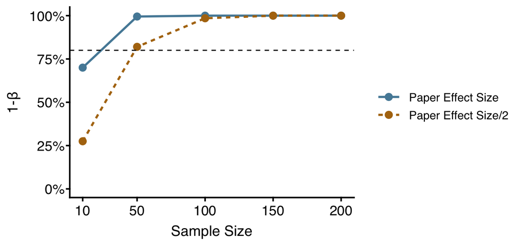

```r
rbind(power %>%
    mutate(effsize = "Paper Effect Size"), power2 %>%
    mutate(effsize = "Paper Effect Size/2")) %>%
    mutate(effsize = factor(effsize, levels = effect_size)) %>%
    mutate(is_significant = ifelse(lwr > 0, TRUE, FALSE)) %>%
    group_by(N, effsize) %>%
    summarise(power = mean(is_significant)) %>%
    ungroup() %>%
    ggplot(aes(N, power)) + geom_line(aes(linetype = effsize, color = effsize), size = 1) +
    geom_point(aes(color = effsize), size = 3) + geom_hline(yintercept = 0.8, linetype = 2) +
    scale_y_continuous(limits = c(0, 1), labels = scales::percent) + scale_x_continuous(breaks = n_sbj_range) +
    labs(x = "Sample Size", y = "1-β") + scale_color_jcolors(palette = "pal6") +
    mytheme() + theme(legend.position = "right")
```

#### Questions

You are going to a sold-out game of your favorite local sport-team, and you have an extra ticket. The price marked on the ticket is $5 but [you were given your tickets for free by a friend / which is what you paid for each ticket / but you paid $10 for each ticket when you bought them from another student].  
You want to get rid of the extra ticket and you know the going price is $5. You find someone who wants the ticket. There is no law against charging more than the price marked on the ticket.

What price do you ask for if…  
a) He is a friend  
b) He is a stranger

What would you have said if you found out that the going market price was $10 instead?  
a) He is a friend  
b) He is a stranger

#### Stan Code

```
data {
  int<lower=1> N;  // total number of observations
  int Y[N];  // response variable
  int<lower=1> K;  // number of population-level effects
  matrix[N, K] X;  // population-level design matrix

  int prior_only;  // should the likelihood be ignored?
}

parameters {
  vector[K] b;  // population-level effects
}

transformed parameters {
}

model {
  // likelihood including constants
  if (!prior_only) {
    vector[N] mu = X * b;
    target += bernoulli_logit_lpmf(Y | mu);
  }
  // priors including constants
  target += normal_lpdf(b | 0, 5);
}
```

## Beer on the beach

#### Power Analysis

```r
# ---- Power Calculation ---- #
nModels <- 5
nChains <- 2
nClusters <- nModels*nChains

n_sim <- 200
n_sbj_range <- c(10, 50, 100, 150, 200, 250, 300)

# Effect found in the paper Thaler 1985
# n_sbj_paper    = 87
store   = c('Resort Hotel', 'Grocery Store')
resort  = 2.65
grocery = 1.5

eff_size = resort - grocery

sim_y <- function(sbj, eff_size){

  resort  = 2.65
  linear_effect <- c( log(resort), log(resort-eff_size) )

  # Calculate the probability of responding 'different'
  inv_link = function(linear_predictor, shape) shape*exp(-linear_predictor)

  store   = c('Resort Hotel', 'Grocery Store')

  # Population Effect
  shape_gamma <- 25
  rate_gamma  <- inv_link(linear_effect, shape_gamma)

  data.frame(subject=sbj, store, response = rgamma(2, shape_gamma, rate_gamma))
}

# -- Run Models in Parallel -- #
samplingfunction<-function(x){

  store   = c('Resort Hotel', 'Grocery Store')
  #Simulate data
  data_sim <- purrr::map_dfr(seq_len(n), sim_y, eff_size=eff_size)

  ## Create Stan Data
  X <- model.matrix(~ store, data_sim)

  #Stan Data
  stan_data <- list(
    N = nrow(data_sim),
    Y = data_sim$response,
    X = X,
    K = ncol(X),

    N_sbj    = n,
    J_sbj    = data_sim$subject,

    prior_only = 0
  )

  fit <- rstan::sampling(gamma_scenario_3,
                         iter    = 2000,
                         chains  = 2,
                         cores   = 2,
                         pars    = 'b',
                         refresh = 0,
                         data    = stan_data,
                         save_warmup = FALSE
                         )
  # s <- summary(fit)
  # if( all(s$summary[,'Rhat']<1.05) ){
    efit <- rstan::extract(fit)

    data.frame(
      estimate = apply(efit$b, 2, mean)[2],
      lwr      = apply(efit$b, 2, quantile, probs=0.025)[2],
      upr      = apply(efit$b, 2, quantile, probs=0.975)[2],
      store    = paste0(store[1], ' - ', store[2]),
      N        = n
    )
  # }

}

samplingfunction2<-function(x){

  store   = c('Resort Hotel', 'Grocery Store')

  #Simulate data
  data_sim <- purrr::map_dfr(seq_len(n), sim_y, eff_size=eff_size/2)

  ## Create Stan Data
  X <- model.matrix(~ store, data_sim)

  #Stan Data
  stan_data <- list(
    N = nrow(data_sim),
    Y = data_sim$response,
    X = X,
    K = ncol(X),

    N_sbj    = n,
    J_sbj    = data_sim$subject,

    prior_only = 0
  )

  fit <- rstan::sampling(gamma_scenario_3,
                         iter    = 2000,
                         chains  = 2,
                         cores   = 2,
                         pars    = 'b',
                         refresh = 0,
                         data    = stan_data,
                         save_warmup = FALSE
                         )

  efit <- rstan::extract(fit)

  # s <- summary(fit)
  # if( all(s$summary[,'Rhat']<1.05) ){
    efit <- rstan::extract(fit)

    data.frame(
      estimate = apply(efit$b, 2, mean)[2],
      lwr      = apply(efit$b, 2, quantile, probs=0.025)[2],
      upr      = apply(efit$b, 2, quantile, probs=0.975)[2],
      store    = paste0(store[1], ' - ', store[2]),
      N        = n
    )
  # }

}

samplingfunction3<-function(x){

  store   = c('Resort Hotel', 'Grocery Store')

  #Simulate data
  data_sim <- purrr::map_dfr(seq_len(n), sim_y, eff_size=eff_size/3)

  ## Create Stan Data
  X <- model.matrix(~ store, data_sim)

  #Stan Data
  stan_data <- list(
    N = nrow(data_sim),
    Y = data_sim$response,
    X = X,
    K = ncol(X),

    N_sbj    = n,
    J_sbj    = data_sim$subject,

    prior_only = 0
  )

  fit <- rstan::sampling(gamma_scenario_3,
                         iter    = 2000,
                         chains  = 2,
                         cores   = 2,
                         pars    = 'b',
                         refresh = 0,
                         data    = stan_data,
                         save_warmup = FALSE
                         )

  efit <- rstan::extract(fit)

  # s <- summary(fit)
  # if( all(s$summary[,'Rhat']<1.05) ){
    efit <- rstan::extract(fit)

    data.frame(
      estimate = apply(efit$b, 2, mean)[2],
      lwr      = apply(efit$b, 2, quantile, probs=0.025)[2],
      upr      = apply(efit$b, 2, quantile, probs=0.975)[2],
      store    = paste0(store[1], ' - ', store[2]),
      N        = n
    )
  # }

}

samplingfunction4<-function(x){

  store   = c('Resort Hotel', 'Grocery Store')

  #Simulate data
  data_sim <- purrr::map_dfr(seq_len(n), sim_y, eff_size=eff_size/4)

  ## Create Stan Data
  X <- model.matrix(~ store, data_sim)

  #Stan Data
  stan_data <- list(
    N = nrow(data_sim),
    Y = data_sim$response,
    X = X,
    K = ncol(X),

    N_sbj    = n,
    J_sbj    = data_sim$subject,

    prior_only = 0
  )

  fit <- rstan::sampling(gamma_scenario_3,
                         iter    = 2000,
                         chains  = 2,
                         cores   = 2,
                         pars    = 'b',
                         refresh = 0,
                         data    = stan_data,
                         save_warmup = FALSE
                         )

  efit <- rstan::extract(fit)

  # s <- summary(fit)
  # if( all(s$summary[,'Rhat']<1.05) ){
    efit <- rstan::extract(fit)

    data.frame(
      estimate = apply(efit$b, 2, mean)[2],
      lwr      = apply(efit$b, 2, quantile, probs=0.025)[2],
      upr      = apply(efit$b, 2, quantile, probs=0.975)[2],
      store    = paste0(store[1], ' - ', store[2]),
      N        = n
    )
  # }

}
```

```r
power <- data.frame()
for (n in n_sbj_range) {
    message("\n\nN Subjects: ", n, "\n")

    message("Setting up Clusters...")
    cl <- parallel::makeCluster(nClusters, outfile = "")
    parallel::clusterExport(cl, c("gamma_scenario_3", "n_sbj_range", "sim_y", "eff_size",
        "n"))

    out <- map_dfr(seq_len(round(n_sim/nModels)), function(i) {
        message("\r", "Simulation: ", i * nModels, "/", n_sim, appendLF = FALSE)
        parallel::parLapply(cl, 1:nModels, samplingfunction)
    })
    power <- rbind(power, out)

    message("Shutting down Clusters...")
    parallel::stopCluster(cl)
}
```

```r
power2 <- data.frame()
for (n in n_sbj_range) {
    message("\n\nN Subjects: ", n, "\n")

    message("Setting up Clusters...")
    cl <- parallel::makeCluster(nClusters, outfile = "")
    parallel::clusterExport(cl, c("gamma_scenario_3", "n_sbj_range", "sim_y", "eff_size",
        "n"))

    out <- map_dfr(seq_len(round(n_sim/nModels)), function(i) {
        message("\r", "Simulation: ", i * nModels, "/", n_sim, appendLF = FALSE)
        parallel::parLapply(cl, 1:nModels, samplingfunction2)
    })
    power2 <- rbind(power2, out)

    message("Shutting down Clusters...")
    parallel::stopCluster(cl)
}
```

```r
power3 <- data.frame()
for (n in n_sbj_range) {
    message("\n\nN Subjects: ", n, "\n")

    message("Setting up Clusters...")
    cl <- parallel::makeCluster(nClusters, outfile = "")
    parallel::clusterExport(cl, c("gamma_scenario_3", "n_sbj_range", "sim_y", "eff_size",
        "n"))

    out <- map_dfr(seq_len(round(n_sim/nModels)), function(i) {
        message("\r", "Simulation: ", i * nModels, "/", n_sim, appendLF = FALSE)
        parallel::parLapply(cl, 1:nModels, samplingfunction3)
    })
    power3 <- rbind(power3, out)

    message("Shutting down Clusters...")
    parallel::stopCluster(cl)
}
```

```r
power4 <- data.frame()
for (n in n_sbj_range) {
    message("\n\nN Subjects: ", n, "\n")

    message("Setting up Clusters...")
    cl <- parallel::makeCluster(nClusters, outfile = "")
    parallel::clusterExport(cl, c("gamma_scenario_3", "n_sbj_range", "sim_y", "eff_size",
        "n"))

    out <- map_dfr(seq_len(round(n_sim/nModels)), function(i) {
        message("\r", "Simulation: ", i * nModels, "/", n_sim, appendLF = FALSE)
        parallel::parLapply(cl, 1:nModels, samplingfunction4)
    })
    power4 <- rbind(power4, out)

    message("Shutting down Clusters...")
    parallel::stopCluster(cl)
}
```

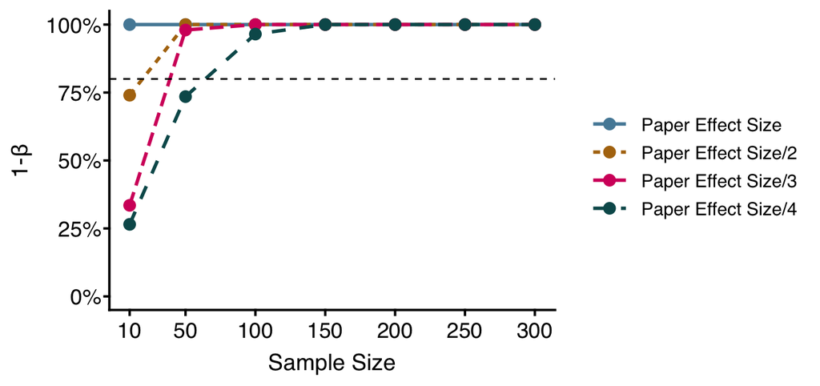

```r
power_line_plot <- rbind(power %>%
    mutate(effsize = "Paper Effect Size"), power2 %>%
    mutate(effsize = "Paper Effect Size/2"), power3 %>%
    mutate(effsize = "Paper Effect Size/3"), power4 %>%
    mutate(effsize = "Paper Effect Size/4")) %>%
    mutate(effsize = factor(effsize, levels = effect_size)) %>%
    mutate(is_significant = ifelse(lwr > 0, TRUE, FALSE)) %>%
    group_by(N, effsize) %>%
    summarise(power = mean(is_significant)) %>%
    ungroup() %>%
    ggplot(aes(N, power)) + geom_line(aes(linetype = effsize, color = effsize), size = 1) +
    geom_point(aes(color = effsize), size = 3) + geom_hline(yintercept = 0.8, linetype = 2) +
    scale_y_continuous(limits = c(0, 1), labels = scales::percent) + scale_x_continuous(breaks = n_sbj_range) +
    labs(x = "Sample Size", y = "1-β") + scale_color_jcolors(palette = "pal6") +
    mytheme() + theme(legend.position = "right")

# power_quantile_plot <- rbind( power %>% mutate(effsize = 'Paper Effect
# Size'), power2 %>% mutate(effsize = 'Paper Effect Size/2'), power3 %>%
# mutate(effsize = 'Paper Effect Size/3'), power4 %>% mutate(effsize = 'Paper
# Effect Size/4') ) %>% ggplot(aes(N, lwr, color = effsize)) +
# stat_pointinterval() + mytheme() + theme(legend.position = 'none') +
# geom_hline(yintercept = 0, linetype=2) + geom_line(data = rbind( power %>%
# mutate(effsize = 'Paper Effect Size'), power2 %>% mutate(effsize = 'Paper
# Effect Size/2'), power3 %>% mutate(effsize = 'Paper Effect Size/3'), power4
# %>% mutate(effsize = 'Paper Effect Size/4')) %>% group_by(N, effsize) %>%
# summarise(m=median(lwr)), aes(N, m, color=effsize)) +
# scale_x_continuous(breaks = NULL) + labs(x='Sample Size', y='2.5% Quantile
# Posterior') + scale_color_jcolors(palette = 'pal6') + #
# scale_color_manual(values = c('gray80', '#6B244C')) + facet_wrap(~effsize)


# plot_grid(plot_grid(NULL, power_line_plot, NULL, rel_widths = c(0.2, 1, 0.2),
# nrow = 1), NULL, power_quantile_plot, rel_heights = c(0.6, 0.1, 1), nrow = 3
# )
power_line_plot
```

#### Questions

You are on the beach on a hot day, and you would really like a cold bottle of beer. A friend offers to go buy the beer from [a fancy resort hotel / a small, run-down grocery store]. They ask how much you are willing to pay for the beer: they will only buy it if it costs as much or less than the price you state. You trust your friend, and there is no possibility of bargaining with the bartender.

What price do you tell them?

#### Stan Code

```stan
data {
  int<lower=1> N;  // total number of observations
  vector[N] Y;  // response variable
  int<lower=1> K;  // number of population-level effects
  matrix[N, K] X;  // population-level design matrix

  int prior_only;  // should the likelihood be ignored?
}

parameters {
  vector[K] b;  // population-level effects
  real<lower=0> shape;  // shape parameter
}

transformed parameters {
}

model {
  // likelihood including constants
  if (!prior_only) {
    // initialize linear predictor term
    vector[N] mu = X * b;
    for (n in 1:N) {
      // apply the inverse link function
      mu[n] = shape * exp(-(mu[n]));
    }
    target += gamma_lpdf(Y | shape, mu);
  }
  // priors including constants
  target += normal_lpdf(b | 0, 5);
  target += gamma_lpdf(shape | 0.01, 0.01);
}
```

```
data {
  int<lower=1> N;  // total number of observations
  vector[N] Y;  // response variable
  int<lower=1> K;  // number of population-level effects
  matrix[N, K] X;  // population-level design matrix

  int prior_only;  // should the likelihood be ignored?
}

parameters {
  vector[K] b;  // population-level effects
  real<lower=0> shape;  // shape parameter
}

transformed parameters {
}

model {
  // likelihood including constants
  if (!prior_only) {
    // initialize linear predictor term
    vector[N] mu = X * b;
    for (n in 1:N) {
      // apply the inverse link function
      mu[n] = shape * exp(-(mu[n]));
    }
    target += gamma_lpdf(Y | shape, mu);
  }
  // priors including constants
  target += normal_lpdf(b | 0, 5);
  target += gamma_lpdf(shape | 0.01, 0.01);
}
```

## Jacket-Calculator

#### Power Analysis

```r
# ---- Power Calculation ---- #
nModels <- 5
nChains <- 2
nClusters <- nModels*nChains

n_sim <- 200
n_sbj_range <- c(10, 50, 100, 150, 200, 250, 300)

# Effect found in the paper Thaler 1985
logit    = function(p) log(p/(1-p))
p_effect = c(0.29, 0.68)
linear_effect <- logit( p_effect )
eff_size = p_effect[2] - p_effect[1]
eff_size = linear_effect[2] - linear_effect[1]

sim_y <- function(sbj, eff_size){

  logit = function(p) log(p/(1-p))

  p_effect    = c(0.29, 0.68)
  price   = c('High', 'Low')
  linear_effect <- logit( p_effect )
  linear_effect[2]  <- linear_effect[1]+eff_size

  # Population Effect
  theta  <- plogis(linear_effect)
  response = rbinom(2, 1, theta)

  data.frame(subject=sbj, price, response)

}

# -- Run Models in Parallel -- #
samplingfunction<-function(x){

  price   = c('Low', 'High')
  #Simulate data
  data_sim <- purrr::map_dfr(seq_len(n), sim_y, eff_size=eff_size)

  ## Create Stan Data

  X <- model.matrix(~ price, data_sim)

  #Stan Data
  stan_data <- list(
    N = nrow(data_sim),
    Y = data_sim$response,
    X = X,
    K = ncol(X),

    N_sbj    = n,
    J_sbj    = data_sim$subject,

    prior_only = 0
  )

  fit <- rstan::sampling(bernoulli_scenario_4,
                         iter    = 2000,
                         chains  = 2,
                         cores   = 2,
                         pars    = 'b',
                         refresh = 0,
                         data    = stan_data,
                         save_warmup = FALSE
                         )

  efit <- rstan::extract(fit)

  data.frame(
    estimate = apply(efit$b, 2, mean)[2],
    lwr      = apply(efit$b, 2, quantile, probs=0.025)[2],
    upr      = apply(efit$b, 2, quantile, probs=0.975)[2],
    store    = paste0(price[1], ' - ', price[2]),
    N        = n
    # Rhat_ok  = all(base::summary(fit)[['summary']][,'Rhat']<1.05)
  )

}

samplingfunction2<-function(x){

  price   = c('Low', 'High')
  #Simulate data
  data_sim <- purrr::map_dfr(seq_len(n), sim_y, eff_size=eff_size/2)

  ## Create Stan Data

  X <- model.matrix(~ price, data_sim)

  #Stan Data
  stan_data <- list(
    N = nrow(data_sim),
    Y = data_sim$response,
    X = X,
    K = ncol(X),

    N_sbj    = n,
    J_sbj    = data_sim$subject,

    prior_only = 0
  )

  fit <- rstan::sampling(bernoulli_scenario_4,
                         iter    = 2000,
                         chains  = 2,
                         cores   = 2,
                         pars    = 'b',
                         refresh = 0,
                         data    = stan_data,
                         save_warmup = FALSE
                         )
  # s <- summary(fit)
  # if( all(s$summary[,'Rhat']<1.05) ){
    efit <- rstan::extract(fit)

    data.frame(
      estimate = apply(efit$b, 2, mean)[2],
      lwr      = apply(efit$b, 2, quantile, probs=0.025)[2],
      upr      = apply(efit$b, 2, quantile, probs=0.975)[2],
      store    = paste0(price[1], ' - ', price[2]),
      N        = n
    )
  # }

}

samplingfunction3<-function(x){

  price   = c('Low', 'High')
  #Simulate data
  data_sim <- purrr::map_dfr(seq_len(n), sim_y, eff_size=eff_size/3)

  ## Create Stan Data

  X <- model.matrix(~ price, data_sim)

  #Stan Data
  stan_data <- list(
    N = nrow(data_sim),
    Y = data_sim$response,
    X = X,
    K = ncol(X),

    N_sbj    = n,
    J_sbj    = data_sim$subject,

    prior_only = 0
  )

  fit <- rstan::sampling(bernoulli_scenario_4,
                         iter    = 2000,
                         chains  = 2,
                         cores   = 2,
                         pars    = 'b',
                         refresh = 0,
                         data    = stan_data,
                         save_warmup = FALSE
                         )
  # s <- summary(fit)
  # if( all(s$summary[,'Rhat']<1.05) ){
    efit <- rstan::extract(fit)

    data.frame(
      estimate = apply(efit$b, 2, mean)[2],
      lwr      = apply(efit$b, 2, quantile, probs=0.025)[2],
      upr      = apply(efit$b, 2, quantile, probs=0.975)[2],
      store    = paste0(price[1], ' - ', price[2]),
      N        = n
    )
  # }

}

samplingfunction4<-function(x){

  price   = c('Low', 'High')
  #Simulate data
  data_sim <- purrr::map_dfr(seq_len(n), sim_y, eff_size=eff_size/4)

  ## Create Stan Data

  X <- model.matrix(~ price, data_sim)

  #Stan Data
  stan_data <- list(
    N = nrow(data_sim),
    Y = data_sim$response,
    X = X,
    K = ncol(X),

    N_sbj    = n,
    J_sbj    = data_sim$subject,

    prior_only = 0
  )

  fit <- rstan::sampling(bernoulli_scenario_4,
                         iter    = 2000,
                         chains  = 2,
                         cores   = 2,
                         pars    = 'b',
                         refresh = 0,
                         data    = stan_data,
                         save_warmup = FALSE
                         )
  # s <- summary(fit)
  # if( all(s$summary[,'Rhat']<1.05) ){
    efit <- rstan::extract(fit)

    data.frame(
      estimate = apply(efit$b, 2, mean)[2],
      lwr      = apply(efit$b, 2, quantile, probs=0.025)[2],
      upr      = apply(efit$b, 2, quantile, probs=0.975)[2],
      store    = paste0(price[1], ' - ', price[2]),
      N        = n
    )
  # }

}
```

```r
power <- data.frame()
for (n in n_sbj_range) {
    message("\n\nN Subjects: ", n, "\n")

    message("Setting up Clusters...")
    cl <- parallel::makeCluster(nClusters, outfile = "")
    parallel::clusterExport(cl, c("bernoulli_scenario_4", "n_sbj_range", "sim_y",
        "eff_size", "n"))

    out <- map_dfr(seq_len(round(n_sim/nModels)), function(i) {
        message("\r", "Simulation: ", i * nModels, "/", n_sim, appendLF = FALSE)
        parallel::parLapply(cl, 1:nModels, samplingfunction)
    })
    power <- rbind(power, out)

    message("Shutting down Clusters...")
    parallel::stopCluster(cl)
}
```

```r
power2 <- data.frame()
for (n in n_sbj_range) {
    message("\n\nN Subjects: ", n)

    message("Setting up Clusters...")
    cl <- parallel::makeCluster(nClusters, outfile = "")
    parallel::clusterExport(cl, c("bernoulli_scenario_4", "n_sbj_range", "sim_y",
        "eff_size", "n"))

    out <- map_dfr(seq_len(round(n_sim/nModels)), function(i) {
        message("\r", "Simulation: ", i * nModels, "/", n_sim, appendLF = FALSE)
        parallel::parLapply(cl, 1:nModels, samplingfunction2)
    })
    power2 <- rbind(power2, out)

    message("Shutting down Clusters...")
    parallel::stopCluster(cl)
}
```

```r
power3 <- data.frame()
for (n in n_sbj_range) {
    message("\n\nN Subjects: ", n, "\n")

    message("Setting up Clusters...")
    cl <- parallel::makeCluster(nClusters, outfile = "")
    parallel::clusterExport(cl, c("bernoulli_scenario_4", "n_sbj_range", "sim_y",
        "eff_size", "n"))

    out <- map_dfr(seq_len(round(n_sim/nModels)), function(i) {
        message("\r", "Simulation: ", i * nModels, "/", n_sim, appendLF = FALSE)
        parallel::parLapply(cl, 1:nModels, samplingfunction3)
    })
    power3 <- rbind(power3, out)

    message("Shutting down Clusters...")
    parallel::stopCluster(cl)
}
```

```r
power4 <- data.frame()
for (n in n_sbj_range) {
    message("\n\nN Subjects: ", n, "\n")

    message("Setting up Clusters...")
    cl <- parallel::makeCluster(nClusters, outfile = "")
    parallel::clusterExport(cl, c("bernoulli_scenario_4", "n_sbj_range", "sim_y",
        "eff_size", "n"))

    out <- map_dfr(seq_len(round(n_sim/nModels)), function(i) {
        message("\r", "Simulation: ", i * nModels, "/", n_sim, appendLF = FALSE)
        parallel::parLapply(cl, 1:nModels, samplingfunction4)
    })
    power4 <- rbind(power4, out)

    message("Shutting down Clusters...")
    parallel::stopCluster(cl)
}
```

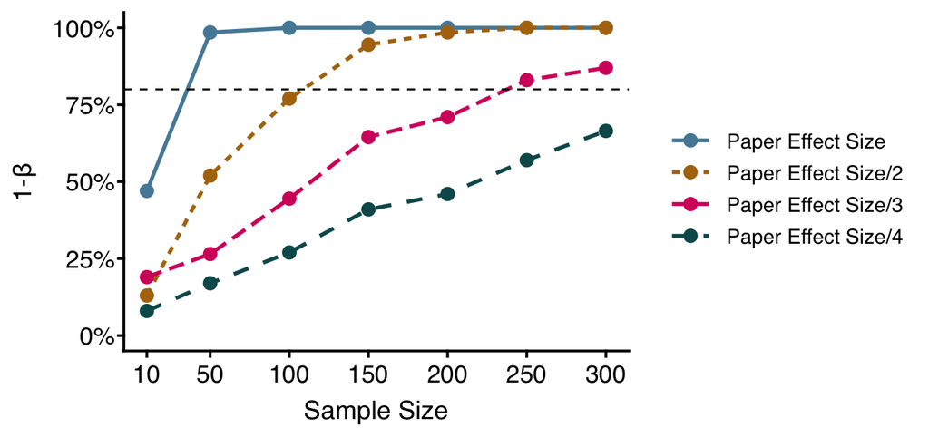

```r
power_line_plot <- rbind(power %>%
    mutate(effsize = "Paper Effect Size"), power2 %>%
    mutate(effsize = "Paper Effect Size/2"), power3 %>%
    mutate(effsize = "Paper Effect Size/3"), power4 %>%
    mutate(effsize = "Paper Effect Size/4")) %>%
    mutate(effsize = factor(effsize, levels = effect_size)) %>%
    mutate(is_significant = ifelse(lwr > 0, TRUE, FALSE)) %>%
    group_by(N, effsize) %>%
    summarise(power = mean(is_significant)) %>%
    ungroup() %>%
    ggplot(aes(N, power)) + geom_line(aes(linetype = effsize, color = effsize), size = 1) +
    geom_point(aes(color = effsize), size = 3) + geom_hline(yintercept = 0.8, linetype = 2) +
    scale_y_continuous(limits = c(0, 1), labels = scales::percent) + scale_x_continuous(breaks = n_sbj_range) +
    labs(x = "Sample Size", y = "1-β") + scale_color_jcolors(palette = "pal6") +
    mytheme() + theme(legend.position = "right")

# power_quantile_plot <- rbind( power %>% mutate(effsize = 'Paper Effect
# Size'), power2 %>% mutate(effsize = 'Paper Effect Size/2'), power3 %>%
# mutate(effsize = 'Paper Effect Size/3'), power4 %>% mutate(effsize = 'Paper
# Effect Size/4') ) %>% ggplot(aes(N, lwr, color = effsize)) +
# stat_pointinterval() + mytheme() + theme(legend.position = 'none') +
# geom_hline(yintercept = 0, linetype=2) + geom_line(data = rbind( power %>%
# mutate(effsize = 'Paper Effect Size'), power2 %>% mutate(effsize = 'Paper
# Effect Size/2'), power3 %>% mutate(effsize = 'Paper Effect Size/3'), power4
# %>% mutate(effsize = 'Paper Effect Size/4')) %>% group_by(N, effsize) %>%
# summarise(m=median(lwr)), aes(N, m, color=effsize)) +
# scale_x_continuous(breaks = NULL) + labs(x='Sample Size', y='2.5% Quantile
# Posterior') + scale_color_jcolors(palette = 'pal6') + #
# scale_color_manual(values = c('gray80', '#6B244C')) + facet_wrap(~effsize)


# plot_grid(plot_grid(power_line_plot, rel_widths = c(0.2, 1, 0.2), nrow = 1),
# NULL, power_quantile_plot, rel_heights = c(0.6, 0.1, 1), nrow = 3 )

power_line_plot
```

#### Questions

You are about to purchase a jacket for [$125 / $15] and a Bluetooth speaker for [$15 / $125]. The salesman informs you that the speaker you wish to buy is on sale for [$10 / $120] at the other branch store, located 20 minutes away.

Would you make the trip to the other store? a) Yes a) No

Imagine that you are about to purchase a jacket for [$125 / $15] and a calculator for [$15 / $125]. The salesman informs you that the calculator you wish to buy is on sale for [$10 / $120] at the other branch store, located 20 minutes away.

Would you make the trip to the other store? a) Yes a) No

#### Stan Code

```r
bernoulli_scenario_4 <- rstan::stan_model("bernoulli_scenario_4.stan")
```

[output not shown]

```
data {
  int<lower=1> N;  // total number of observations
  int Y[N];  // response variable
  int<lower=1> K;  // number of population-level effects
  matrix[N, K] X;  // population-level design matrix

  int prior_only;  // should the likelihood be ignored?
}

parameters {
  vector[K] b;  // population-level effects
}

transformed parameters {
}

model {
  // likelihood including constants
  if (!prior_only) {
    vector[N] mu = X * b;
    target += bernoulli_logit_lpmf(Y | mu);
  }
  // priors including constants
  target += normal_lpdf(b | 0, 5);
}
```

## Lost Ticket

#### Power Analysis

```r
# ---- Power Calculation ---- #
nModels <- 5
nChains <- 2
nClusters <- nModels*nChains

n_sim <- 200
n_sbj_range <- c(10, 50, 100, 150, 200, 250, 300)

# Effect found in the paper Thaler 1985
logit    = function(p) log(p/(1-p))
loss       = c('Cash', 'Ticket')
p_effect    = c(0.88, 0.46)

linear_effect <- logit( p_effect )
eff_size = linear_effect[2] - linear_effect[1]

sim_y <- function(sbj, eff_size){

  logit = function(p) log(p/(1-p))

  loss       = c('Cash', 'Ticket')
  p_effect    = c(0.88, 0.46)
  linear_effect <- logit( p_effect )
  linear_effect[2]  <- linear_effect[1]+eff_size

  # Population Effect
  theta  <- plogis(linear_effect)
  response = rbinom(2, 1, theta)

  data.frame(subject=sbj, loss, response)

}

# -- Run Models in Parallel -- #
samplingfunction<-function(x){

  loss       = c('Cash', 'Ticket')
  #Simulate data
  data_sim <- purrr::map_dfr(seq_len(n), sim_y, eff_size=eff_size)

  ## Create Stan Data

  X <- model.matrix(~ loss, data_sim)

  #Stan Data
  stan_data <- list(
    N = nrow(data_sim),
    Y = data_sim$response,
    X = X,
    K = ncol(X),

    N_sbj    = n,
    J_sbj    = data_sim$subject,

    prior_only = 0
  )

  fit <- rstan::sampling(bernoulli_scenario_4,
                         iter    = 2000,
                         chains  = 2,
                         cores   = 2,
                         pars    = 'b',
                         refresh = 0,
                         data    = stan_data,
                         save_warmup = FALSE
                         )

  efit <- rstan::extract(fit)

  data.frame(
    estimate = apply(efit$b, 2, mean)[2],
    lwr      = apply(efit$b, 2, quantile, probs=0.025)[2],
    upr      = apply(efit$b, 2, quantile, probs=0.975)[2],
    store    = paste0(loss[2], ' - ', loss[1]),
    N        = n
    # Rhat_ok  = all(base::summary(fit)[['summary']][,'Rhat']<1.05)
  )

}

samplingfunction2<-function(x){

  loss       = c('Cash', 'Ticket')
  #Simulate data
  data_sim <- purrr::map_dfr(seq_len(n), sim_y, eff_size=eff_size/2)

  ## Create Stan Data

  X <- model.matrix(~ loss, data_sim)

  #Stan Data
  stan_data <- list(
    N = nrow(data_sim),
    Y = data_sim$response,
    X = X,
    K = ncol(X),

    N_sbj    = n,
    J_sbj    = data_sim$subject,

    prior_only = 0
  )

  fit <- rstan::sampling(bernoulli_scenario_4,
                         iter    = 2000,
                         chains  = 2,
                         cores   = 2,
                         pars    = 'b',
                         refresh = 0,
                         data    = stan_data,
                         save_warmup = FALSE
                         )
  # s <- summary(fit)
  # if( all(s$summary[,'Rhat']<1.05) ){
    efit <- rstan::extract(fit)

    data.frame(
      estimate = apply(efit$b, 2, mean)[2],
      lwr      = apply(efit$b, 2, quantile, probs=0.025)[2],
      upr      = apply(efit$b, 2, quantile, probs=0.975)[2],
      store    = paste0(loss[2], ' - ', loss[1]),
      N        = n
    )
  # }

}

samplingfunction3<-function(x){

  loss       = c('Cash', 'Ticket')
  #Simulate data
  data_sim <- purrr::map_dfr(seq_len(n), sim_y, eff_size=eff_size/3)

  ## Create Stan Data

  X <- model.matrix(~ loss, data_sim)

  #Stan Data
  stan_data <- list(
    N = nrow(data_sim),
    Y = data_sim$response,
    X = X,
    K = ncol(X),

    N_sbj    = n,
    J_sbj    = data_sim$subject,

    prior_only = 0
  )

  fit <- rstan::sampling(bernoulli_scenario_4,
                         iter    = 2000,
                         chains  = 2,
                         cores   = 2,
                         pars    = 'b',
                         refresh = 0,
                         data    = stan_data,
                         save_warmup = FALSE
                         )
  # s <- summary(fit)
  # if( all(s$summary[,'Rhat']<1.05) ){
    efit <- rstan::extract(fit)

    data.frame(
      estimate = apply(efit$b, 2, mean)[2],
      lwr      = apply(efit$b, 2, quantile, probs=0.025)[2],
      upr      = apply(efit$b, 2, quantile, probs=0.975)[2],
      store    = paste0(loss[2], ' - ', loss[1]),
      N        = n
    )
  # }

}

samplingfunction4<-function(x){

  loss       = c('Cash', 'Ticket')
  #Simulate data
  data_sim <- purrr::map_dfr(seq_len(n), sim_y, eff_size=eff_size/4)

  ## Create Stan Data

  X <- model.matrix(~ loss, data_sim)

  #Stan Data
  stan_data <- list(
    N = nrow(data_sim),
    Y = data_sim$response,
    X = X,
    K = ncol(X),

    N_sbj    = n,
    J_sbj    = data_sim$subject,

    prior_only = 0
  )

  fit <- rstan::sampling(bernoulli_scenario_4,
                         iter    = 2000,
                         chains  = 2,
                         cores   = 2,
                         pars    = 'b',
                         refresh = 0,
                         data    = stan_data,
                         save_warmup = FALSE
                         )
  # s <- summary(fit)
  # if( all(s$summary[,'Rhat']<1.05) ){
    efit <- rstan::extract(fit)

    data.frame(
      estimate = apply(efit$b, 2, mean)[2],
      lwr      = apply(efit$b, 2, quantile, probs=0.025)[2],
      upr      = apply(efit$b, 2, quantile, probs=0.975)[2],
      store    = paste0(loss[2], ' - ', loss[1]),
      N        = n
    )
  # }

}
```

```r
# ---- Power Calculation ---- #
power <- data.frame()
for (n in n_sbj_range) {
    message("\n\nN Subjects: ", n, "\n")

    message("Setting up Clusters...")
    cl <- parallel::makeCluster(nClusters, outfile = "")
    parallel::clusterExport(cl, c("bernoulli_scenario_4", "n_sbj_range", "sim_y",
        "eff_size", "n"))

    out <- map_dfr(seq_len(round(n_sim/nModels)), function(i) {
        message("\r", "Simulation: ", i * nModels, "/", n_sim, appendLF = FALSE)
        parallel::parLapply(cl, 1:nModels, samplingfunction)
    })
    power <- rbind(power, out)

    message("Shutting down Clusters...")
    parallel::stopCluster(cl)
}
```

```r
# ---- Power Calculation ---- #
power2 <- data.frame()
for (n in n_sbj_range) {
    message("\n\nN Subjects: ", n)

    message("Setting up Clusters...")
    cl <- parallel::makeCluster(nClusters, outfile = "")
    parallel::clusterExport(cl, c("bernoulli_scenario_4", "n_sbj_range", "sim_y",
        "eff_size", "n"))

    out <- map_dfr(seq_len(round(n_sim/nModels)), function(i) {
        message("\r", "Simulation: ", i * nModels, "/", n_sim, appendLF = FALSE)
        parallel::parLapply(cl, 1:nModels, samplingfunction2)
    })
    power2 <- rbind(power2, out)

    message("Shutting down Clusters...")
    parallel::stopCluster(cl)
}
```

```r
# ---- Power Calculation ---- #
power3 <- data.frame()
for (n in n_sbj_range) {
    message("\n\nN Subjects: ", n, "\n")

    message("Setting up Clusters...")
    cl <- parallel::makeCluster(nClusters, outfile = "")
    parallel::clusterExport(cl, c("bernoulli_scenario_4", "n_sbj_range", "sim_y",
        "eff_size", "n"))

    out <- map_dfr(seq_len(round(n_sim/nModels)), function(i) {
        message("\r", "Simulation: ", i * nModels, "/", n_sim, appendLF = FALSE)
        parallel::parLapply(cl, 1:nModels, samplingfunction3)
    })
    power3 <- rbind(power3, out)

    message("Shutting down Clusters...")
    parallel::stopCluster(cl)
}
```

```r
power4 <- data.frame()
for (n in n_sbj_range) {
    message("\n\nN Subjects: ", n, "\n")

    message("Setting up Clusters...")
    cl <- parallel::makeCluster(nClusters, outfile = "")
    parallel::clusterExport(cl, c("bernoulli_scenario_4", "n_sbj_range", "sim_y",
        "eff_size", "n"))

    out <- map_dfr(seq_len(round(n_sim/nModels)), function(i) {
        message("\r", "Simulation: ", i * nModels, "/", n_sim, appendLF = FALSE)
        parallel::parLapply(cl, 1:nModels, samplingfunction4)
    })
    power4 <- rbind(power4, out)

    message("Shutting down Clusters...")
    parallel::stopCluster(cl)
}
```

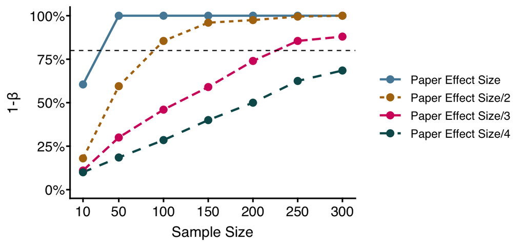

```r
power_line_plot <- rbind(power %>%
    mutate(effsize = "Paper Effect Size"), power2 %>%
    mutate(effsize = "Paper Effect Size/2"), power3 %>%
    mutate(effsize = "Paper Effect Size/3"), power4 %>%
    mutate(effsize = "Paper Effect Size/4")) %>%
    mutate(effsize = factor(effsize, levels = effect_size)) %>%
    mutate(is_significant = ifelse(upr < 0, TRUE, FALSE)) %>%
    group_by(N, effsize) %>%
    summarise(power = mean(is_significant)) %>%
    ungroup() %>%
    ggplot(aes(N, power)) + geom_line(aes(linetype = effsize, color = effsize), size = 1) +
    geom_point(aes(color = effsize), size = 3) + geom_hline(yintercept = 0.8, linetype = 2) +
    scale_y_continuous(limits = c(0, 1), labels = scales::percent) + scale_x_continuous(breaks = n_sbj_range) +
    labs(x = "Sample Size", y = "1-β") + scale_color_jcolors(palette = "pal6") +
    mytheme() + theme(legend.position = "right")

# power_quantile_plot <- rbind( power %>% mutate(effsize = 'Paper Effect
# Size'), power2 %>% mutate(effsize = 'Paper Effect Size/2'), power3 %>%
# mutate(effsize = 'Paper Effect Size/3'), power4 %>% mutate(effsize = 'Paper
# Effect Size/4') ) %>% ggplot(aes(N, upr, color = effsize)) +
# stat_pointinterval() + mytheme() + theme(legend.position = 'none') +
# geom_hline(yintercept = 0, linetype=2) + geom_line(data = rbind( power %>%
# mutate(effsize = 'Paper Effect Size'), power2 %>% mutate(effsize = 'Paper
# Effect Size/2'), power3 %>% mutate(effsize = 'Paper Effect Size/3'), power4
# %>% mutate(effsize = 'Paper Effect Size/4')) %>% group_by(N, effsize) %>%
# summarise(m=median(upr)), aes(N, m, color=effsize)) +
# scale_x_continuous(breaks = NULL) + labs(x='Sample Size', y='2.5% Quantile
# Posterior') + scale_color_jcolors(palette = 'pal6') + #
# scale_color_manual(values = c('gray80', '#6B244C')) + facet_wrap(~effsize)

# plot_grid(plot_grid(power_line_plot, rel_widths = c(0.2, 1, 0.2), nrow = 1),
# NULL, power_quantile_plot, rel_heights = c(0.6, 0.1, 1), nrow = 3 )

power_line_plot
```

#### Questions

Imagine you are on your way to a play with [a pair of tickets for which you have paid $40 / the intention of buying two tickets worth $40 in total]. On entering the theater, you discover that [you have lost the tickets / you have lost $40 in cash].

Would you pay $40 for another pair of tickets? a) Yes b) No

#### Stan Code

```
data {
  int<lower=1> N;  // total number of observations
  int Y[N];  // response variable
  int<lower=1> K;  // number of population-level effects
  matrix[N, K] X;  // population-level design matrix

  int prior_only;  // should the likelihood be ignored?
}

parameters {
  vector[K] b;  // population-level effects
}

transformed parameters {
}

model {
  // likelihood including constants
  if (!prior_only) {
    vector[N] mu = X * b;
    target += bernoulli_logit_lpmf(Y | mu);
  }
  // priors including constants
  target += normal_lpdf(b | 0, 5);
}
```

## Membership gym

#### Power Analysis

```r
# ---- Power Calculation ---- #
nModels <- 5
nChains <- 2
nClusters <- nModels*nChains

n_sim <- 200
n_sbj_range <- c(10, 50, 100, 150, 200, 250, 300)

# Effect found in the paper Thaler 1985
logit    = function(p) log(p/(1-p))
frame    = c(0, 1) # Yearly - Per-session
p_effect = c(0.18, 0.78)

linear_effect <- logit( p_effect )
eff_size = linear_effect[2] - linear_effect[1]

sim_y <- function(sbj, eff_size){

  logit = function(p) log(p/(1-p))

  frame    = c(0, 1) # Yearly - Per-session
  p_effect = c(0.18, 0.78)
  linear_effect <- logit( p_effect )
  linear_effect[2]  <- linear_effect[1]+eff_size
  std = 0.5

  # Random Effect
  re <- rnorm(1, 0, std)
  # Population Effect
  theta  <- plogis(linear_effect+re)
  response = rbinom(2, 1, theta)

  data.frame(subject=sbj, frame, response)

}

# -- Run Models in Parallel -- #
samplingfunction<-function(x){

  #Simulate data
  data_sim <- purrr::map_dfr(seq_len(n), sim_y, eff_size=eff_size)

  ## Create Stan Data

  X <- model.matrix(~ frame, data_sim)

  #Stan Data
  stan_data <- list(
    N = nrow(data_sim),
    Y = data_sim$response,
    X = X,
    K = ncol(X),

    prior_only = 0
  )

  fit <- rstan::sampling(bernoulli_scenario_6,
                         iter    = 2000,
                         chains  = 2,
                         cores   = 2,
                         pars    = 'b',
                         refresh = 0,
                         data    = stan_data,
                         save_warmup = FALSE
                         )

  efit <- rstan::extract(fit)

  data.frame(
    estimate = apply(efit$b, 2, mean)[2],
    lwr      = apply(efit$b, 2, quantile, probs=0.025)[2],
    upr      = apply(efit$b, 2, quantile, probs=0.975)[2],
    store    = paste0('Per-session - Yearly'),
    N        = n
  )

}

samplingfunction2<-function(x){

  #Simulate data
  data_sim <- purrr::map_dfr(seq_len(n), sim_y, eff_size=eff_size/2)

  ## Create Stan Data

  X <- model.matrix(~ frame, data_sim)

  #Stan Data
  stan_data <- list(
    N = nrow(data_sim),
    Y = data_sim$response,
    X = X,
    K = ncol(X),

    prior_only = 0
  )

  fit <- rstan::sampling(bernoulli_scenario_6,
                         iter    = 2000,
                         chains  = 2,
                         cores   = 2,
                         pars    = 'b',
                         refresh = 0,
                         data    = stan_data,
                         save_warmup = FALSE
                         )

  efit <- rstan::extract(fit)

  data.frame(
    estimate = apply(efit$b, 2, mean)[2],
    lwr      = apply(efit$b, 2, quantile, probs=0.025)[2],
    upr      = apply(efit$b, 2, quantile, probs=0.975)[2],
    store    = paste0('Per-session - Yearly'),
    N        = n
  )

}

samplingfunction3<-function(x){

  #Simulate data
  data_sim <- purrr::map_dfr(seq_len(n), sim_y, eff_size=eff_size/3)

  ## Create Stan Data

  X <- model.matrix(~ frame, data_sim)

  #Stan Data
  stan_data <- list(
    N = nrow(data_sim),
    Y = data_sim$response,
    X = X,
    K = ncol(X),

    prior_only = 0
  )

  fit <- rstan::sampling(bernoulli_scenario_6,
                         iter    = 2000,
                         chains  = 2,
                         cores   = 2,
                         pars    = 'b',
                         refresh = 0,
                         data    = stan_data,
                         save_warmup = FALSE
                         )

  efit <- rstan::extract(fit)

  data.frame(
    estimate = apply(efit$b, 2, mean)[2],
    lwr      = apply(efit$b, 2, quantile, probs=0.025)[2],
    upr      = apply(efit$b, 2, quantile, probs=0.975)[2],
    store    = paste0('Per-session - Yearly'),
    N        = n
  )

}

samplingfunction4<-function(x){

  #Simulate data
  data_sim <- purrr::map_dfr(seq_len(n), sim_y, eff_size=eff_size/4)

  ## Create Stan Data

  X <- model.matrix(~ frame, data_sim)

  #Stan Data
  stan_data <- list(
    N = nrow(data_sim),
    Y = data_sim$response,
    X = X,
    K = ncol(X),

    prior_only = 0
  )

  fit <- rstan::sampling(bernoulli_scenario_6,
                         iter    = 2000,
                         chains  = 2,
                         cores   = 2,
                         pars    = 'b',
                         refresh = 0,
                         data    = stan_data,
                         save_warmup = FALSE
                         )

  efit <- rstan::extract(fit)

  data.frame(
    estimate = apply(efit$b, 2, mean)[2],
    lwr      = apply(efit$b, 2, quantile, probs=0.025)[2],
    upr      = apply(efit$b, 2, quantile, probs=0.975)[2],
    store    = paste0('Per-session - Yearly'),
    N        = n
  )

}
```

```r
# ---- Power Calculation ---- #
power <- data.frame()
for (n in n_sbj_range) {
    message("\n\nN Subjects: ", n, "\n")

    message("Setting up Clusters...")
    cl <- parallel::makeCluster(nClusters, outfile = "")
    parallel::clusterExport(cl, c("bernoulli_scenario_6", "n_sbj_range", "sim_y",
        "eff_size", "n"))

    out <- map_dfr(seq_len(round(n_sim/nModels)), function(i) {
        message("\r", "Simulation: ", i * nModels, "/", n_sim, appendLF = FALSE)
        parallel::parLapply(cl, 1:nModels, samplingfunction)
    })
    power <- rbind(power, out)

    message("Shutting down Clusters...")
    parallel::stopCluster(cl)
}
```

```r
# ---- Power Calculation ---- #
power2 <- data.frame()
for (n in n_sbj_range) {
    message("\n\nN Subjects: ", n)

    message("Setting up Clusters...")
    cl <- parallel::makeCluster(nClusters, outfile = "")
    parallel::clusterExport(cl, c("bernoulli_scenario_6", "n_sbj_range", "sim_y",
        "eff_size", "n"))

    out <- map_dfr(seq_len(round(n_sim/nModels)), function(i) {
        message("\r", "Simulation: ", i * nModels, "/", n_sim, appendLF = FALSE)
        parallel::parLapply(cl, 1:nModels, samplingfunction2)
    })
    power2 <- rbind(power2, out)

    message("Shutting down Clusters...")
    parallel::stopCluster(cl)
}
```

```r
# ---- Power Calculation ---- #
power3 <- data.frame()
for (n in n_sbj_range) {
    message("\n\nN Subjects: ", n, "\n")

    message("Setting up Clusters...")
    cl <- parallel::makeCluster(nClusters, outfile = "")
    parallel::clusterExport(cl, c("bernoulli_scenario_6", "n_sbj_range", "sim_y",
        "eff_size", "n"))

    out <- map_dfr(seq_len(round(n_sim/nModels)), function(i) {
        message("\r", "Simulation: ", i * nModels, "/", n_sim, appendLF = FALSE)
        parallel::parLapply(cl, 1:nModels, samplingfunction3)
    })
    power3 <- rbind(power3, out)

    message("Shutting down Clusters...")
    parallel::stopCluster(cl)
}
```

```r
power4 <- data.frame()
for (n in n_sbj_range) {
    message("\n\nN Subjects: ", n, "\n")

    message("Setting up Clusters...")
    cl <- parallel::makeCluster(nClusters, outfile = "")
    parallel::clusterExport(cl, c("bernoulli_scenario_6", "n_sbj_range", "sim_y",
        "eff_size", "n"))

    out <- map_dfr(seq_len(round(n_sim/nModels)), function(i) {
        message("\r", "Simulation: ", i * nModels, "/", n_sim, appendLF = FALSE)
        parallel::parLapply(cl, 1:nModels, samplingfunction4)
    })
    power4 <- rbind(power4, out)

    message("Shutting down Clusters...")
    parallel::stopCluster(cl)
}
```

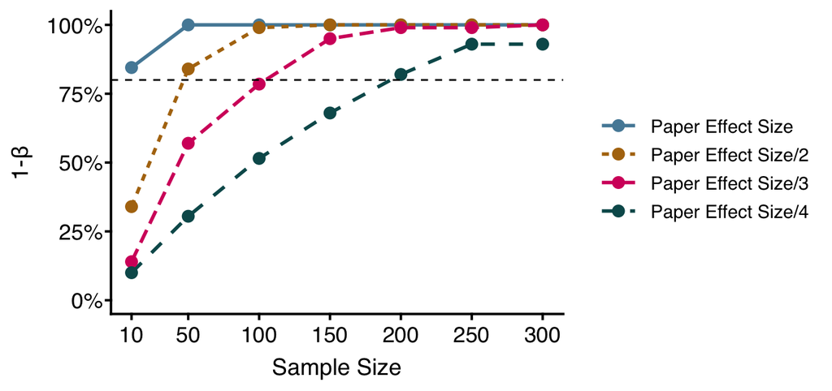

```r
power_line_plot <- rbind(power %>%
    mutate(effsize = "Paper Effect Size"), power2 %>%
    mutate(effsize = "Paper Effect Size/2"), power3 %>%
    mutate(effsize = "Paper Effect Size/3"), power4 %>%
    mutate(effsize = "Paper Effect Size/4")) %>%
    mutate(effsize = factor(effsize, levels = effect_size)) %>%
    mutate(is_significant = ifelse(lwr > 0, TRUE, FALSE)) %>%
    group_by(N, effsize) %>%
    summarise(power = mean(is_significant)) %>%
    ungroup() %>%
    ggplot(aes(N, power)) + geom_line(aes(linetype = effsize, color = effsize), size = 1) +
    geom_point(aes(color = effsize), size = 3) + geom_hline(yintercept = 0.8, linetype = 2) +
    scale_y_continuous(limits = c(0, 1), labels = scales::percent) + scale_x_continuous(breaks = n_sbj_range) +
    labs(x = "Sample Size", y = "1-β") + scale_color_jcolors(palette = "pal6") +
    mytheme() + theme(legend.position = "right")

# power_quantile_plot <- rbind( power %>% mutate(effsize = 'Paper Effect
# Size'), power2 %>% mutate(effsize = 'Paper Effect Size/2'), power3 %>%
# mutate(effsize = 'Paper Effect Size/3'), power4 %>% mutate(effsize = 'Paper
# Effect Size/4') ) %>% ggplot(aes(N, lwr, color = effsize)) +
# stat_pointinterval() + mytheme() + theme(legend.position = 'none') +
# geom_hline(yintercept = 0, linetype=2) + geom_line(data = rbind( power %>%
# mutate(effsize = 'Paper Effect Size'), power2 %>% mutate(effsize = 'Paper
# Effect Size/2'), power3 %>% mutate(effsize = 'Paper Effect Size/3'), power4
# %>% mutate(effsize = 'Paper Effect Size/4')) %>% group_by(N, effsize) %>%
# summarise(m=median(lwr)), aes(N, m, color=effsize)) +
# scale_x_continuous(breaks = NULL) + labs(x='Sample Size', y='2.5% Quantile
# Posterior') + scale_color_jcolors(palette = 'pal6') + #
# scale_color_manual(values = c('gray80', '#6B244C')) + facet_wrap(~effsize)

# plot_grid(plot_grid(power_line_plot, rel_widths = c(0.2, 1, 0.2), nrow = 1),
# NULL, power_quantile_plot, rel_heights = c(0.6, 0.1, 1), nrow = 3 )

power_line_plot
```

#### Questions

You have a gym membership in a nearby town that you travel to on a regular basis. You go to this gym every single Monday night. The membership allows you to pay [$20 (non-refundable) per session / $1000 a year (i.e., roughly $20 per visit)]. One Monday, just after you have arrived and changed into your gym clothes, you receive a phone call that requires you to leave and forego your exercise that evening.

Which of the following statements better captures your feelings about the cost of the missed workout? a) I feel like I wasted $20 b) I feel like I wasted nothing, since my visit had already been paid for c) I feel like I wasted something, but no specific amount or measure comes to mind

#### Stan Code

```r
bernoulli_scenario_6 <- rstan::stan_model("bernoulli_scenario_6.stan")
```

```
data {
  int<lower=1> N;  // total number of observations
  int Y[N];  // response variable
  int<lower=1> K;  // number of population-level effects
  matrix[N, K] X;  // population-level design matrix

  int prior_only;  // should the likelihood be ignored?
}

parameters {
  vector[K] b;  // population-level effects
}

transformed parameters {
}

model {
  // likelihood including constants
  if (!prior_only) {
    vector[N] mu = X * b;
    target += bernoulli_logit_lpmf(Y | mu);
  }
  // priors including constants
  target += normal_lpdf(b | 0, 5);
}
```

## Airplanes coupons

#### Power Analysis

```r
# ---- Power Calculation ---- #
nModels <- 5
nChains <- 2
nClusters <- nModels*nChains

n_sim <- 200
n_sbj_range <- c(10, 50, 100, 150, 200, 250, 300)

# Effect found in the paper Thaler 1985
logit    = function(p) log(p/(1-p))
coupon   = c(0, 1) # Free - Purchased
p_effect = c(0.05, 0.25)

linear_effect <- logit( p_effect )
eff_size = linear_effect[2] - linear_effect[1]

sim_y <- function(sbj, eff_size){

  logit = function(p) log(p/(1-p))

  coupon   = c(0, 1) # Free - Purchased
  p_effect = c(0.05, 0.25)
  linear_effect <- logit( p_effect )
  linear_effect[2]  <- linear_effect[1]+eff_size
  std = 0.5

  # Random Effect
  re <- rnorm(1, 0, std)
  # Population Effect
  theta  <- plogis(linear_effect+re)
  response = rbinom(2, 1, theta)

  data.frame(subject=sbj, coupon, response)

}

# -- Run Models in Parallel -- #
samplingfunction<-function(x){

  #Simulate data
  data_sim <- purrr::map_dfr(seq_len(n), sim_y, eff_size=eff_size)

  ## Create Stan Data

  X <- model.matrix(~ coupon, data_sim)

  #Stan Data
  stan_data <- list(
    N = nrow(data_sim),
    Y = data_sim$response,
    X = X,
    K = ncol(X),

    prior_only = 0
  )

  fit <- rstan::sampling(bernoulli_scenario_6,
                         iter    = 2000,
                         chains  = 2,
                         cores   = 2,
                         pars    = 'b',
                         refresh = 0,
                         data    = stan_data,
                         save_warmup = FALSE
                         )

  efit <- rstan::extract(fit)

  data.frame(
    estimate = apply(efit$b, 2, mean)[2],
    lwr      = apply(efit$b, 2, quantile, probs=0.025)[2],
    upr      = apply(efit$b, 2, quantile, probs=0.975)[2],
    store    = paste0('Purchased - Free'),
    N        = n
  )

}

samplingfunction2<-function(x){

  #Simulate data
  data_sim <- purrr::map_dfr(seq_len(n), sim_y, eff_size=eff_size/2)

  ## Create Stan Data

  X <- model.matrix(~ coupon, data_sim)

  #Stan Data
  stan_data <- list(
    N = nrow(data_sim),
    Y = data_sim$response,
    X = X,
    K = ncol(X),

    prior_only = 0
  )

  fit <- rstan::sampling(bernoulli_scenario_6,
                         iter    = 2000,
                         chains  = 2,
                         cores   = 2,
                         pars    = 'b',
                         refresh = 0,
                         data    = stan_data,
                         save_warmup = FALSE
                         )

  efit <- rstan::extract(fit)

  data.frame(
    estimate = apply(efit$b, 2, mean)[2],
    lwr      = apply(efit$b, 2, quantile, probs=0.025)[2],
    upr      = apply(efit$b, 2, quantile, probs=0.975)[2],
    store    = paste0('Purchased - Free'),
    N        = n
  )

}

samplingfunction3<-function(x){

  #Simulate data
  data_sim <- purrr::map_dfr(seq_len(n), sim_y, eff_size=eff_size/3)

  ## Create Stan Data

  X <- model.matrix(~ coupon, data_sim)

  #Stan Data
  stan_data <- list(
    N = nrow(data_sim),
    Y = data_sim$response,
    X = X,
    K = ncol(X),

    prior_only = 0
  )

  fit <- rstan::sampling(bernoulli_scenario_6,
                         iter    = 2000,
                         chains  = 2,
                         cores   = 2,
                         pars    = 'b',
                         refresh = 0,
                         data    = stan_data,
                         save_warmup = FALSE
                         )

  efit <- rstan::extract(fit)

  data.frame(
    estimate = apply(efit$b, 2, mean)[2],
    lwr      = apply(efit$b, 2, quantile, probs=0.025)[2],
    upr      = apply(efit$b, 2, quantile, probs=0.975)[2],
    store    = paste0('Purchased - Free'),
    N        = n
  )

}

samplingfunction4<-function(x){

  #Simulate data
  data_sim <- purrr::map_dfr(seq_len(n), sim_y, eff_size=eff_size/4)

  ## Create Stan Data

  X <- model.matrix(~ coupon, data_sim)

  #Stan Data
  stan_data <- list(
    N = nrow(data_sim),
    Y = data_sim$response,
    X = X,
    K = ncol(X),

    prior_only = 0
  )

  fit <- rstan::sampling(bernoulli_scenario_6,
                         iter    = 2000,
                         chains  = 2,
                         cores   = 2,
                         pars    = 'b',
                         refresh = 0,
                         data    = stan_data,
                         save_warmup = FALSE
                         )

  efit <- rstan::extract(fit)

  data.frame(
    estimate = apply(efit$b, 2, mean)[2],
    lwr      = apply(efit$b, 2, quantile, probs=0.025)[2],
    upr      = apply(efit$b, 2, quantile, probs=0.975)[2],
    store    = paste0('Purchased - Free'),
    N        = n
  )

}
```

```r
# ---- Power Calculation ---- #
power <- data.frame()
for (n in n_sbj_range) {
    message("\n\nN Subjects: ", n, "\n")

    message("Setting up Clusters...")
    cl <- parallel::makeCluster(nClusters, outfile = "")
    parallel::clusterExport(cl, c("bernoulli_scenario_6", "n_sbj_range", "sim_y",
        "eff_size", "n"))

    out <- map_dfr(seq_len(round(n_sim/nModels)), function(i) {
        message("\r", "Simulation: ", i * nModels, "/", n_sim, appendLF = FALSE)
        parallel::parLapply(cl, 1:nModels, samplingfunction)
    })
    power <- rbind(power, out)

    message("Shutting down Clusters...")
    parallel::stopCluster(cl)
}
```

```r
# ---- Power Calculation ---- #
power2 <- data.frame()
for (n in n_sbj_range) {
    message("\n\nN Subjects: ", n)

    message("Setting up Clusters...")
    cl <- parallel::makeCluster(nClusters, outfile = "")
    parallel::clusterExport(cl, c("bernoulli_scenario_6", "n_sbj_range", "sim_y",
        "eff_size", "n"))

    out <- map_dfr(seq_len(round(n_sim/nModels)), function(i) {
        message("\r", "Simulation: ", i * nModels, "/", n_sim, appendLF = FALSE)
        parallel::parLapply(cl, 1:nModels, samplingfunction2)
    })
    power2 <- rbind(power2, out)

    message("Shutting down Clusters...")
    parallel::stopCluster(cl)
}
```

```r
# ---- Power Calculation ---- #
power3 <- data.frame()
for (n in n_sbj_range) {
    message("\n\nN Subjects: ", n, "\n")

    message("Setting up Clusters...")
    cl <- parallel::makeCluster(nClusters, outfile = "")
    parallel::clusterExport(cl, c("bernoulli_scenario_6", "n_sbj_range", "sim_y",
        "eff_size", "n"))

    out <- map_dfr(seq_len(round(n_sim/nModels)), function(i) {
        message("\r", "Simulation: ", i * nModels, "/", n_sim, appendLF = FALSE)
        parallel::parLapply(cl, 1:nModels, samplingfunction3)
    })
    power3 <- rbind(power3, out)

    message("Shutting down Clusters...")
    parallel::stopCluster(cl)
}
```

```r
power4 <- data.frame()
for (n in n_sbj_range) {
    message("\n\nN Subjects: ", n, "\n")

    message("Setting up Clusters...")
    cl <- parallel::makeCluster(nClusters, outfile = "")
    parallel::clusterExport(cl, c("bernoulli_scenario_6", "n_sbj_range", "sim_y",
        "eff_size", "n"))

    out <- map_dfr(seq_len(round(n_sim/nModels)), function(i) {
        message("\r", "Simulation: ", i * nModels, "/", n_sim, appendLF = FALSE)
        parallel::parLapply(cl, 1:nModels, samplingfunction4)
    })
    power4 <- rbind(power4, out)

    message("Shutting down Clusters...")
    parallel::stopCluster(cl)
}
```

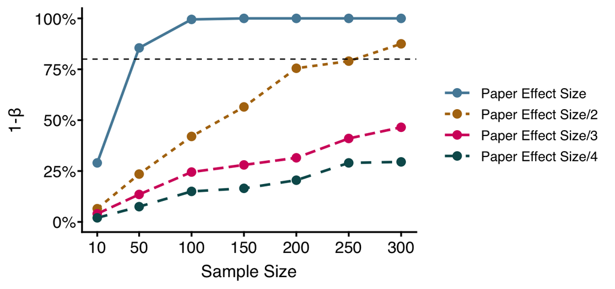

```r
power_line_plot <- rbind(power %>%
    mutate(effsize = "Paper Effect Size"), power2 %>%
    mutate(effsize = "Paper Effect Size/2"), power3 %>%
    mutate(effsize = "Paper Effect Size/3"), power4 %>%
    mutate(effsize = "Paper Effect Size/4")) %>%
    mutate(effsize = factor(effsize, levels = effect_size)) %>%
    mutate(is_significant = ifelse(lwr > 0, TRUE, FALSE)) %>%
    group_by(N, effsize) %>%
    summarise(power = mean(is_significant)) %>%
    ungroup() %>%
    ggplot(aes(N, power)) + geom_line(aes(linetype = effsize, color = effsize), size = 1) +
    geom_point(aes(color = effsize), size = 3) + geom_hline(yintercept = 0.8, linetype = 2) +
    scale_y_continuous(limits = c(0, 1), labels = scales::percent) + scale_x_continuous(breaks = n_sbj_range) +
    labs(x = "Sample Size", y = "1-β") + scale_color_jcolors(palette = "pal6") +
    mytheme() + theme(legend.position = "right")

# power_quantile_plot <- rbind( power %>% mutate(effsize = 'Paper Effect
# Size'), power2 %>% mutate(effsize = 'Paper Effect Size/2'), power3 %>%
# mutate(effsize = 'Paper Effect Size/3'), power4 %>% mutate(effsize = 'Paper
# Effect Size/4') ) %>% ggplot(aes(N, lwr, color = effsize)) +
# stat_pointinterval() + mytheme() + theme(legend.position = 'none') +
# geom_hline(yintercept = 0, linetype=2) + geom_line(data = rbind( power %>%
# mutate(effsize = 'Paper Effect Size'), power2 %>% mutate(effsize = 'Paper
# Effect Size/2'), power3 %>% mutate(effsize = 'Paper Effect Size/3'), power4
# %>% mutate(effsize = 'Paper Effect Size/4')) %>% group_by(N, effsize) %>%
# summarise(m=median(lwr)), aes(N, m, color=effsize)) +
# scale_x_continuous(breaks = NULL) + labs(x='Sample Size', y='2.5% Quantile
# Posterior') + scale_color_jcolors(palette = 'pal6') + #
# scale_color_manual(values = c('gray80', '#6B244C')) + facet_wrap(~effsize)


# plot_grid(plot_grid(power_line_plot, rel_widths = c(0.2, 1, 0.2), nrow = 1),
# NULL, power_quantile_plot, rel_heights = c(0.6, 0.1, 1), nrow = 3 )

power_line_plot
```

#### Questions

You are flying with a friend who has upgraded their ticket to business class and has two coupons, each worth $35, which can be used to upgrade your ticket/seat from economy to business class. They purchased one coupon for the standard price of $35 and received the other one for free. Just one coupon is required to upgrade your class on the current flight, and your friend offers you the coupon [which he purchased / which he got for free] so that you can upgrade as well.

What do you think is the most appropriate thing to do? a) Pay your friend $35 for the coupon. b) Consider it a gift and not pay for the coupon. c) Pay some, but not the full amount for the coupon (for example, half the price).

#### Stan Code

```
data {
  int<lower=1> N;  // total number of observations
  int Y[N];  // response variable
  int<lower=1> K;  // number of population-level effects
  matrix[N, K] X;  // population-level design matrix

  int prior_only;  // should the likelihood be ignored?
}

parameters {
  vector[K] b;  // population-level effects
}

transformed parameters {
}

model {
  // likelihood including constants
  if (!prior_only) {
    vector[N] mu = X * b;
    target += bernoulli_logit_lpmf(Y | mu);
  }
  // priors including constants
  target += normal_lpdf(b | 0, 5);
}
```